# An Introduction to Statistical Learning (2013)

Solutions to Exercises

by Brian Hassett

# Chapter 4 Conceptual Exercises

This notebook outlines solutions to the conceptual exercises in Chapter 4 of **An Introduction to Statistical Learning** (James et al. (2013)[^1]).

## Exercise 1

*Using a little bit of algebra, prove that (4.2) is equivalent to (4.3). In other words, the logistic function representation and logit representation for the logistic regression model are equivalent.*

Starting with equation (4.2), manipulate it into equation (4.3):

$$p(X)=\frac{e^{\beta_{0}+\beta_{1}X}}{1+e^{\beta_{0}+\beta_{1}X}} \hspace{2cm} (4.2)$$
$$p(X)(1+e^{\beta_{0}+\beta_{1}X})=e^{\beta_{0}+\beta_{1}X}$$
$$p(X)+p(X)e^{\beta_{0}+\beta_{1}X}=e^{\beta_{0}+\beta_{1}X}$$
$$p(X)=e^{\beta_{0}+\beta_{1}X}-p(X)e^{\beta_{0}+\beta_{1}X}$$
$$p(X)=e^{\beta_{0}+\beta_{1}X}(1-p(X))$$
$$\frac{p(X)}{1-p(X)}=e^{\beta_{0}+\beta_{1}X} \hspace{2cm} (4.3) \square$$

## Exercise 2

*It was stated in the text that classifying an observation to the class for which (4.12) is largest is equivalent to classifying an observation to the class for which (4.13) is largest. Prove that this is the case. In other words, under the assumption that the observations in the $k$th class are drawn from a $N(\mu_k, \sigma^2)$ distribution, the Bayes’ classifier assigns an observation to the class for which the discriminant function is maximized.*

Bayes’ theorem gives us
$$\operatorname{Pr}(Y=k | X=x) = \frac{\pi_{k} f_{k}(x)}{\sum_{l=1}^{K} \pi_{l} f_{l}(x)}, \hspace{2cm} (4.10)$$
and the normal density function is
$$f_{k}(x)=\frac{1}{\sqrt{2 \pi} \sigma_{k}} \exp \left(-\frac{1}{2 \sigma_{k}^{2}}\left(x-\mu_{k}\right)^{2}\right). \hspace{2cm} (4.11)$$

Plugging (4.11) into (4.10) and using the abbreviation $p_{k}(x) = \operatorname{Pr}(Y=k | X=x)$ gives us:
$$p_{k}(x)=\frac{\pi_{k} \frac{1}{\sqrt{2 \pi} \sigma} \exp \left(-\frac{1}{2 \sigma^{2}}\left(x-\mu_{k}\right)^{2}\right)}{\sum_{l=1}^{K} \pi_{l} \frac{1}{\sqrt{2 \pi} \sigma} \exp \left(-\frac{1}{2 \sigma^{2}}\left(x-\mu_{l}\right)^{2}\right)}. \hspace{2cm} (4.12)$$

To classify an observation, the Bayes classifier assigns an observation to the class for which (4.12) is largest.

We can derive the discriminant function by taking the log of both sides:
$$\log{\left(p_{k}(x)\right)}=\log\left(\frac{\pi_{k} \frac{1}{\sqrt{2 \pi} \sigma} \exp \left(-\frac{1}{2 \sigma^{2}}\left(x-\mu_{k}\right)^{2}\right)}{\sum_{l=1}^{K} \pi_{l} \frac{1}{\sqrt{2 \pi} \sigma} \exp \left(-\frac{1}{2 \sigma^{2}}\left(x-\mu_{l}\right)^{2}\right)}\right)$$
$$\log{\left(p_{k}(x)\right)}=\log{\left( \pi_{k} \frac{1}{\sqrt{2 \pi} \sigma} \exp \left(-\frac{1}{2 \sigma^{2}}\left(x-\mu_{k}\right)^{2}\right) \right)} - \log{\left( \sum_{l=1}^{K} \pi_{l} \frac{1}{\sqrt{2 \pi} \sigma} \exp \left(-\frac{1}{2 \sigma^{2}}\left(x-\mu_{l}\right)^{2}\right) \right)}$$
Note that the term $\sum_{l=1}^{K} \pi_{l} \frac{1}{\sqrt{2 \pi} \sigma} \exp \left(-\frac{1}{2 \sigma^{2}}\left(x-\mu_{l}\right)^{2}\right)$ is independent of $k$. Therefore $\log{\left(p_{k}(x)\right)}$ is largest when $\log{\left( \pi_{k} \frac{1}{\sqrt{2 \pi} \sigma} \exp \left(-\frac{1}{2 \sigma^{2}}\left(x-\mu_{k}\right)^{2}\right) \right)}$ is largest. Rearrange this expression:
$$\log{\left( \pi_{k} \frac{1}{\sqrt{2 \pi} \sigma} \exp \left(-\frac{1}{2 \sigma^{2}}\left(x-\mu_{k}\right)^{2}\right) \right)}$$
$$\log{\left( \pi_{k} \frac{1}{\sqrt{2 \pi} \sigma } \right) + \log \left( \exp \left(-\frac{1}{2 \sigma^{2}}\left(x-\mu_{k}\right)^{2}\right) \right)}$$
$$\log\left({\pi_{k}}\frac{1}{\sqrt{2 \pi} \sigma}\right) + \left(-\frac{1}{2 \sigma^{2}}(x-\mu_{k})^{2}\right)$$
$$\log{(\pi_{k})} + \log{\left(\frac{1}{\sqrt{2 \pi} \sigma}\right)} - \frac{1}{2 \sigma^{2}}(x^2-2x\mu_{k}+\mu_{k}^2)$$
$$\log{(\pi_{k})} + \log{\left(\frac{1}{\sqrt{2 \pi} \sigma}\right)} - \frac{1}{2 \sigma^{2}}x^2 + \frac{1}{2 \sigma^{2}}2x\mu_{k} - \frac{1}{2 \sigma^{2}}\mu_{k}^2$$
$$\log{\left(\frac{1}{\sqrt{2 \pi} \sigma}\right)} - x^2.\frac{1}{2 \sigma^{2}} + x.\frac{\mu_{k}}{\sigma^{2}} - \frac{\mu_{k}^2}{2 \sigma^{2}} + \log{(\pi_{k})}$$

We wish to obtain the largest value for this expression across all values of $k$. Therefore we can remove the terms which are independent of $k$; $\log{\left(\frac{1}{\sqrt{2 \pi} \sigma}\right)}$ and $-x^2\frac{1}{2 \sigma^{2}}$. The value of the remaining expression is $\delta_{k}(x)$, the discriminant function:
$$\delta_{k}(x)=x.\frac{\mu_{k}}{\sigma^{2}} - \frac{\mu_{k}^2}{2 \sigma^{2}} + \log{(\pi_{k})}. \hspace{2cm} (4.13)$$
Therefore classifying an observation to the class for which (4.12) is largest is equivalent to classifying an observation to the class for which (4.13) is largest. $\square$

## Exercise 3

*This problem relates to the QDA model, in which the observations within each class are drawn from a normal distribution with a class-specific mean vector and a class specific covariance matrix. We consider the simple case where $p = 1$; i.e. there is only one feature.*

*Suppose that we have $K$ classes, and that if an observation belongs to the $k$th class then $X$ comes from a one-dimensional normal distribution, $X ∼ N (\mu_k, \sigma_k^2)$. Recall that the density function for the one-dimensional normal distribution is given in (4.11). Prove that in this case, the Bayes’ classifier is not linear. Argue that it is in fact quadratic.*

*Hint: For this problem, you should follow the arguments laid out in Section 4.4.2, but without making the assumption that $\sigma_1^2 = \dots = \sigma_k^2$.*

Bayes’ theorem gives us:
$$\operatorname{Pr}(Y=k | X=x) = \frac{\pi_{k} f_{k}(x)}{\sum_{l=1}^{K} \pi_{l} f_{l}(x)}, \hspace{2cm} (4.10)$$
and the normal density function is
$$f_{k}(x)=\frac{1}{\sqrt{2 \pi} \sigma_{k}} \exp \left(-\frac{1}{2 \sigma_{k}^{2}}\left(x-\mu_{k}\right)^{2}\right). \hspace{2cm} (4.11)$$

Using the abbreviation $p_{k}(x) = \operatorname{Pr}(Y=k | X=x)$ substitute in the expression for $f_{k}(x)$:

$$p_{k}(x)=\frac{\pi_{k} \frac{1}{\sqrt{2 \pi} \sigma_{k}} \exp \left(-\frac{1}{2 \sigma_{k}^{2}}\left(x-\mu_{k}\right)^{2}\right)}{\sum_{l=1}^{K} \pi_{l} \frac{1}{\sqrt{2 \pi} \sigma_{l}} \exp \left(-\frac{1}{2 \sigma_{l}^{2}}\left(x-\mu_{l}\right)^{2}\right)}$$
Take the log of both sides:
$$\log\left(p_{k}(x)\right) = \log\left(\frac{\pi_{k} \frac{1}{\sqrt{2 \pi} \sigma_{k}} \exp \left(-\frac{1}{2 \sigma_{k}^{2}}\left(x-\mu_{k}\right)^{2}\right)}{\sum_{l=1}^{K} \pi_{l} \frac{1}{\sqrt{2 \pi} \sigma_{l}} \exp \left(-\frac{1}{2 \sigma_{l}^{2}}\left(x-\mu_{l}\right)^{2}\right)}\right)$$
$$\log\left(p_{k}(x)\right) = \log\left(\pi_{k} \frac{1}{\sqrt{2 \pi} \sigma_{k}} \exp \left(-\frac{1}{2 \sigma_{k}^{2}}\left(x-\mu_{k}\right)^{2}\right)\right) - \log\left(\sum_{l=1}^{K} \pi_{l} \frac{1}{\sqrt{2 \pi} \sigma_{l}} \exp \left(-\frac{1}{2 \sigma_{l}^{2}}\left(x-\mu_{l}\right)^{2}\right)\right)$$
Note that the term $\sum_{l=1}^{K} \pi_{l} \frac{1}{\sqrt{2 \pi} \sigma_{l}} \exp \left(-\frac{1}{2 \sigma_{l}^{2}}\left(x-\mu_{l}\right)^{2}\right)$ is independent of $k$. Therefore $\log{\left(p_{k}(x)\right)}$ is largest when $\log\left(\pi_{k} \frac{1}{\sqrt{2 \pi} \sigma_{k}} \exp \left(-\frac{1}{2 \sigma_{k}^{2}}\left(x-\mu_{k}\right)^{2}\right)\right)$ is largest.

Rearrange this expression:
$$\log\left(\pi_{k} \frac{1}{\sqrt{2 \pi} \sigma_{k}} \exp \left(-\frac{1}{2 \sigma_{k}^{2}}\left(x-\mu_{k}\right)^{2}\right)\right)$$

$$\log\left({\pi_{k}}\frac{1}{\sqrt{2 \pi} \sigma_{k}}\right) + \left(-\frac{1}{2 \sigma_{k}^{2}}(x-\mu_{k})^{2}\right)$$
$$\log{(\pi_{k})} + \log{\left(\frac{1}{\sqrt{2 \pi} \sigma_{k}}\right)} - \frac{1}{2 \sigma_{k}^{2}}(x^2-2x\mu_{k}+\mu_{k}^2)$$
$$\log{(\pi_{k})} + \log\left(\frac{1}{\sqrt{2 \pi}}\right) + \log{\left(\frac{1}{\sigma_{k}}\right)} - \frac{1}{2 \sigma_{k}^{2}}x^2 + \frac{1}{2 \sigma_{k}^{2}}2x\mu_{k} - \frac{1}{2 \sigma_{k}^{2}}\mu_{k}^2$$
$$- x^2.\frac{1}{2 \sigma_{k}^{2}} + x.\frac{\mu_{k}}{\sigma_{k}^{2}} - \frac{\mu_{k}^2}{2 \sigma_{k}^{2}} + \log\left(\frac{1}{\sqrt{2 \pi}}\right) + \log{\left(\frac{1}{\sigma_{k}}\right)} + \log{(\pi_{k})}$$

The term $\log\left(\frac{1}{\sqrt{2 \pi}}\right)$ is independent of $k$. The remaining terms form an expression for the discriminant function:
$$\delta_{k}(x) = - x^2.\frac{1}{2 \sigma_{k}^{2}} + x.\frac{\mu_{k}}{\sigma_{k}^{2}} - \frac{\mu_{k}^2}{2 \sigma_{k}^{2}} + \log\left(\frac{1}{\sigma_{k}}\right) + \log(\pi_{k})$$
As $\delta_{k}(x)$ is **quadratic** in $x$, we can say that the Bayes’ Classifier is quadratic. $\square$

## Exercise 4

*This solution uses a logical and intuitive approach to the problem. A more rigorous solution requires application of probability theory.*

*When the number of features $p$ is large, there tends to be a deterioration in the performance of KNN and other local approaches that perform prediction using only observations that are near the test observation for which a prediction must be made. This phenomenon is known as the curse of dimensionality, and it ties into the fact that non-parametric approaches often perform poorly when $p$ is large. We will now investigate this curse.*

1. *Suppose that we have a set of observations, each with measurements on $p = 1$ feature, $X$. We assume that $X$ is uniformly (evenly) distributed on $[0, 1]$. Associated with each observation is a response value. Suppose that we wish to predict a test observation’s response using only observations that are within 10% of the range of $X$ closest to that test observation. For instance, in order to predict the response for a test observation with $X = 0.6$, we will use observations in the range $[0.55, 0.65]$. On average, what fraction of the available observations will we use to make the prediction?*
2. *Now suppose that we have a set of observations, each with measurements on $p = 2$ features, $X_1$ and $X_2$ . We assume that $(X_1, X_2)$ are uniformly distributed on $[0, 1] \times [0, 1]$. We wish to predict a test observation’s response using only observations that are within 10% of the range of $X_1$ and within 10% of the range of $X_2$ closest to that test observation. For instance, in order to predict the response for a test observation with $X_1 = 0.6$ and $X_2 = 0.35$, we will use observations in the range $[0.55, 0.65]$ for $X_1$ and in the range $[0.3, 0.4]$ for $X_2$ . On average, what fraction of the available observations will we use to make the prediction?*
3. *Now suppose that we have a set of observations on $p = 100$ features. Again the observations are uniformly distributed on each feature, and again each feature ranges in value from $0$ to $1$. We wish to predict a test observation’s response using observations within the 10% of each feature’s range that is closest to that test observation. What fraction of the available observations will we use to make the prediction?*
4. *Using your answers to parts (a)–(c), argue that a drawback of KNN when $p$ is large is that there are very few training observations “near” any given test observation.*
5. *Now suppose that we wish to make a prediction for a test observation by creating a p-dimensional hypercube centered around the test observation that contains, on average, 10 % of the training observations. For $p = 1$, $2$, and $100$, what is the length of each side of the hypercube? Comment on your answer.*

### (a)

With $p=1$, we have one feature, $X$. To predict a test observation’s response, we use the observations that are within 10% of the range of $X$ closest to that test observation. Since $X\sim U(0, 1)$, it’s clear that, on average, **10%** of the observations will be used to make the prediction.

### (b)

With $p=2$, we have two features, $X_{1}$ and $X_{2}$, with $(X_{1}, X_{2})$ uniformly distributed on $[0,1]\times[0,1]$. To predict a test observation’s response, we use the observations that are within 10% of the range of $X_{1}$ **and** within 10% of the range of $X_{2}$ closest to that test observation. From part (a) we know that, on average, 10% of the observations will have an $X_{1}$ value that falls within the $X_{1}$ range. Using the same logic, we can say that 10% of these observations will have an $X_{2}$ value that falls within the $X_{2}$ range. This leaves us with an average of **1%** (10% of 10%) of the observations which fall within both ranges.

### (c)

In part (b), with $p=2$, we saw that 10% of 10% of the observations fell within the two ranges. We can say that the fraction of observations which are used is $(0.1)^p=0.01$, where $p=2$. This formula also works for part (a) where we can say that the fraction of observations used is $(0.1)^1=0.1$, i.e. 10%. Therefore in the case of 100 features we can say that the average fraction of observations used is $(0.1)^{100}=10^{-100}$. The equivalent percentage is 10<sup>-98</sup>%.

### (d)

As $p$ increases, there are exponentially less observations “near” each test observation. We saw in part (c) with $p=100$ features, there are essentially no nearby observations satisfying the ‘within 10% of the range’ rule. Therefore with a large number of features, KNN may use far away observations in predicting classes, leading to poor results.

### (e)

For $p=1$ the hypercube is a one-dimensional line segment. In order to predict the response for a test observation with $X = 0.5$, we will use observations in the range $[0.45, 0.55]$. From part (a) and the fact that $X\sim U(0, 1)$, it’s clear that, on average, a fraction of 0.1 (10%) of the observations will fall in this range. The below plot shows 1,000 points sampled from $X$. The orange shaded area is where 10% of the observations are expected to lie and which would be used for prediction. The width of this shaded area is $l=0.1$, which is the length of the hypercube for $p=1$.

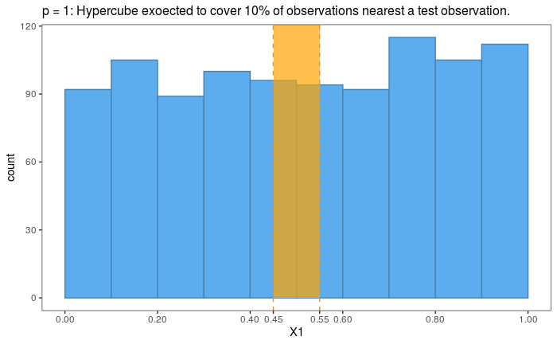

For $p=2$ the hypercube is a square. The below plot shows 1,000 points sampled from $(X_{1}, X_{2})$. We know from part (b) that a fraction of 0.01 (1%) of the observations will be used to make a prediction for a test observation. This corresponds to one square outlined by the blue grid on the plot. In order to use 0.1 (10%) of the observations, the square would need to be 10 times ($0.1 / 0.01$) bigger in area. This gives a new area of 0.1 ($10 \times 0.01$). The side length of this square is $l=\sqrt{0.1}$, or, in terms of $p$, $l=(0.1)^{1/p}$.

Using this value for $l$, in order to predict the response for a test observation $(0.5, 0.5)$, we will use observations within a square centered at $(0.5, 0.5)$ and with side length $l=\sqrt{0.1}$. This corresponds to the orange shaded area in the below plot.

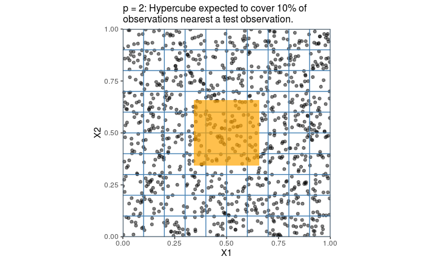

Using the same logic, in the case of $p=100$, the length of the hypercube containing, on average, 10% of the observations, is $l=(0.1)^{1/100} = 0.9772372$. If we project the 100-dimensional hypercube on to the two-dimensional plane, we can see what the resulting shaded are looks like in the plot below.

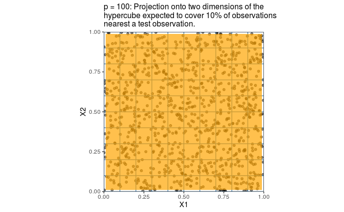

It looks like almost the entire plane has been covered by the shaded region. It’s hard to see how this corresponds to 10% of the total observations. But this is only a projection of the 100-d hypercube onto a plane. We can calculate the volume of the 100-d hypercube which is not covered by this shaded area as $1 - \left((0.1)^{1/100}\right)^{100} = 0.9$. As required, 90% of the volume of the 100-d hypercube falls outside the shaded area in 100 dimensions.

## Exercise 5

*We now examine the differences between LDA and QDA.*

1. *If the Bayes decision boundary is linear, do we expect LDA or QDA to perform better on the training set? On the test set?*
2. *If the Bayes decision boundary is non-linear, do we expect LDA or QDA to perform better on the training set? On the test set?*
3. *In general, as the sample size n increases, do we expect the test prediction accuracy of QDA relative to LDA to improve, decline, or be unchanged? Why?*
4. *True or False: Even if the Bayes decision boundary for a given problem is linear, we will probably achieve a superior test error rate using QDA rather than LDA because QDA is flexible enough to model a linear decision boundary. Justify your answer.*

### (a)

- Training set: QDA
- Test set: LDA

Regardless of the Bayes decision boundary, the more flexible model, QDA, will perform better on the training set as it will be able to fit the data better. However, if the Bayes decision boundary is linear, then the more flexible model may have overfit the data leading to poor performance on the test set. Therefore LDA is expected to perform better on the test set.

### (b)

- Training set: QDA
- Test set: QDA

As in part (a), we expect the more flexible model, QDA, to perform better on the training set. However, if the Bayes decision boundary is non-linear we expect that QDA will also perform better on the test set. Being a more flexible model, QDA will be able to capture some of the non-linearity of the boundary.

### (c)

As the sample size increases, the variance of predictions is reduced.

### (d)

False. As in part (a), the more flexible QDA model may overfit the training data (particularly any noise in the data) leading to poorer test performance. The less flexible LDA model would be expected to perform better on the test set because it is less prone to overfitting the training data.

## Exercise 6

*Suppose we collect data for a group of students in a statistics class with variables $X_1$ = hours studied, $X_2$ = undergrad GPA, and $Y$ = receive an A. We fit a logistic regression and produce estimated coefficient, $\hat{\beta_0} = -6$, $\hat{\beta_1} = 0.05$, $\hat{\beta_2} = 1$.*

1. *Estimate the probability that a student who studies for 40 hours and has an undergrad GPA of 3.5 gets an A in the class.*
2. *How many hours would the student in part (a) need to study to have a 50% chance of getting an A in the class?*

*Variables*: $X_{1}$ = hours studied; $X_{2}$ = undergrad GPA; $Y$ = receive an A.  
*Coefficients*: $\hat{\beta}_{0}=-6$; $\hat{\beta}_{1}=0.05$; $\hat{\beta}_{2}=1$

### (a)

From (4.7):
$$\hat{p}(X_{1},X_{2})=\frac{e^{\hat{\beta}_{0}+\hat{\beta}_{1}X_{1}+\hat{\beta}_{2} X_{2}}}{1+e^{\hat{\beta}_{0}+\hat{\beta}_{1}X_{1}+\hat{\beta}_{2}X_{2}}}$$
$$\hat{p}(40,3.5)=\frac{e^{-6+\hat{\beta}_{1}X_{1}+\hat{\beta}_{1} X_{2}}}{1+e^{\hat{\beta}_{0}+\hat{\beta}_{1}X_{1}+\hat{\beta}_{1}X_{2}}}$$

$$\hat{p}(40,3.5)=\frac{e^{(-6)+(0.05)(40)+ (1)(3.5)}}{1+e^{(-6)+(0.05)(40)+ (1)(3.5)}}$$
$$\hat{p}(40,3.5)=0.3775407$$

Calculate using `R`:

```r
exp((-6)+(0.05)*(40)+(1)*(3.5)) / (1 + exp(-6+(0.05)*(40)+(1)*(3.5)))
```

```
[1] 0.3775407
```

### (b)

$$\hat{p}(X_{1},X_{2})=\frac{e^{\hat{\beta}_{0}+\hat{\beta}_{1}X_{1}+\hat{\beta}_{2} X_{2}}}{1+e^{\hat{\beta}_{0}+\hat{\beta}_{1}X_{1}+\hat{\beta}_{2}X_{2}}}$$
$$0.5=\frac{e^{(-6)+(0.05)(x_{1})+ (1)(3.5)}}{1+e^{(-6)+(0.05)(x_{1})+ (1)(3.5)}}$$
$$0.5=\frac{e^{(-2.5+0.05x_{1})}}{1+e^{(-2.5+0.05x_{1})}}$$
$$0.5(1+e^{(-2.5+0.05x_{1})})=e^{(-2.5+0.05x_{1})}$$
$$0.5 + 0.5(e^{(-2.5+0.05x_{1})})=e^{(-2.5+0.05x_{1})}$$
$$0.5(e^{(-2.5+0.05x_{1})})=0.5$$
$$e^{(-2.5+0.05x_{1})}=1$$
$$\log(e^{(-2.5+0.05x_{1})})=\log(1)$$
$$(-2.5+0.05x_{1})=(0)$$
$$0.05x_{1}=2.5$$
$$x_{1}=\frac{2.5}{0.05}$$
$$x_{1}=50$$

## Exercise 7

*Suppose that we wish to predict whether a given stock will issue a dividend this year (“Yes” or “No”) based on $X$, last year’s percent profit. We examine a large number of companies and discover that the mean value of $X$ for companies that issued a dividend was $\bar{X} = 10$, while the mean for those that didn’t was $\bar{X} = 0$. In addition, the variance of $X$ for these two sets of companies was $\sigma^2 = 36$. Finally, 80% of companies issued dividends. Assuming that $X$ follows a normal distribution, predict the probability that a company will issue a dividend this year given that its percentage profit was $X = 4$ last year.*

$Y=\{0,1\},\text{where 0}\equiv\text{No dividend paid, 1}\equiv\text{Dividend paid}$.  
$\hat{\mu}_{0}=0, \hat{\mu}_{1}=10$  
$\hat{\sigma}_{0}^2=\hat{\sigma}_{1}^2=36;\text{let }\hat{\sigma}^2=36,\hat{\sigma}=6$  
$\hat{\pi}_0=0.2, \hat{\pi}_1=0.8$

Using (4.12):
$$p_{k}(x)=\frac{\pi_{k} \frac{1}{\sqrt{2 \pi} \sigma} \exp \left(-\frac{1}{2 \sigma^{2}}\left(x-\mu_{k}\right)^{2}\right)}{\sum_{l=1}^{K} \pi_{l} \frac{1}{\sqrt{2 \pi} \sigma} \exp \left(-\frac{1}{2 \sigma^{2}}\left(x-\mu_{l}\right)^{2}\right)}$$
$$\hat{p}_{1}(4)=\frac{(0.8) \frac{1}{\sqrt{2 \pi} (6)} \exp \left(-\frac{1}{2 (36)}\left(4-(10)\right)^{2}\right)}{\left((0.2) \frac{1}{\sqrt{2 \pi} (6)} \exp \left(-\frac{1}{2 (36)}\left(4-(0)\right)^{2}\right)\right) + \left((0.8) \frac{1}{\sqrt{2 \pi} (6)} \exp \left(-\frac{1}{2 (36)}\left(4-(10)\right)^{2}\right)\right)}$$

$$\hat{p}_{1}(4)=\frac{(0.8) \exp(-1/2)} {(0.2) \exp(-2/9) + (0.8) \exp(-1/2)}$$
$$\hat{p}_{1}(4)\approx 0.7518525$$

Calculate using `R`:

```r
p = (0.8 * exp(-1/2)) / ((0.2 * exp(-2/9)) + (0.8 * exp(-1/2)))
p
```

```
[1] 0.7518525
```

## Exercise 8

*Suppose that we take a data set, divide it into equally-sized training and test sets, and then try out two different classification procedures. First we use logistic regression and get an error rate of 20% on the training data and 30% on the test data. Next we use 1-nearest neighbors (i.e. $K = 1$) and get an average error rate (averaged over both test and training data sets) of 18%. Based on these results, which method should we prefer to use for classification of new observations? Why?*

With KNN, the training error with $k=1$ is zero. This is because the nearest neighbor to any data point is itself and the model fits the training data perfectly. Therefore the test error for KNN in this case is $2\times18\%=36\%$. An error rate of $36\%$ is worse than the logistic regression model’s error of $30\%$. Therefore the logistic regression model should be used for new observations.

## Exercise 9

*This problem has to do with odds.*

1. *On average, what fraction of people with an odds of 0.37 of defaulting on their credit card payment will in fact default?*
2. *Suppose that an individual has a 16 % chance of defaulting on her credit card payment. What are the odds that she will default?*

### (a)

Using (4.3):
$$\frac{p(X)}{1-p(X)}=0.37$$
$$p(X) = 0.37(1-p(X))$$
$$p(X) = 0.37-0.37p(X)$$
$$1.37p(X) = 0.37$$
$$p(X) = 0.270073$$

### (b)

Using (4.3):
$$p(X)=0.16$$
$$\frac{p(X)}{1-p(X)} = \frac{0.16}{1-0.16}$$
$$\frac{p(X)}{1-p(X)} = 0.1904762$$

[^1]: James G, Witten D, Hastie T, Tibshirani R (2013). *An Introduction to Statistical Learning: with Applications in R*. Springer, 1st edition.